# Introduction to Z-Transform

## Recommended Resources

For understanding the Z-transform and some solved examples refer to the following:

- [Z-transform part1 - digital signal processing - شرح بالعربي](https://www.youtube.com/watch?v=4eWoxyAYwZc)
- [Z-transform part2 digital signal processing - شرح بالعربي](https://www.youtube.com/watch?v=3Nd0H1xfbv0&list=PLorCHRL47i3GVpP7ed-6fTx7_-SkAYtQd&index=4)
- [Inverse z-transform - digital signal processing - شرح بالعربي](https://www.youtube.com/watch?v=g1s_0_toKuE&list=PLorCHRL47i3GVpP7ed-6fTx7_-SkAYtQd&index=3)

For understanding the mapping between S and Z domain visualization:

- [Understanding the Z-Transform](https://www.youtube.com/watch?v=7Gl4kJUjp4c)

For proof of different properties:

- [Neso Academy](https://www.youtube.com/watch?v=mJgVOV9jRZU&list=PLBlnK6fEyqRhMF6jWHU5LgxAp2Wax6P_K&index=1)

## From Laplace to Z-Transform

We know that we use the Laplace transform to work with continuous signals: $$ X(s) = \int_{0}^{\infty} x(t) e^{-st} dt = \int_{0}^{\infty} x(t) e^{-(\sigma + j\omega)t} dt = \int_{0}^{\infty} x(t) {\color{red}e^{-\sigma t}} {\color{blue}e^{-j\omega t}} dt $$ Laplace transform can give information about a continuous signal such as the region of stability, locations of poles and zeros, causality, etc., but it only works with continuous signals.

[figure not shown]

The **DTFT** (Discrete-Time Fourier Transform) solves this problem by allowing us to work with discrete signals: $$ X(e^{j\omega}) = \sum x[n]e^{-j\omega n} $$ It allows us to see the frequency response, but we can't identify the location of poles and zeros easily, as we only see the behavior on the imaginary axis (i.e., at $\sigma = 0$).

- **Frequency response**
- **Spectrum**

But it **cannot** give you:

- **Poles and zeros**
- **Stability conditions**
- **Regions of convergence (ROC)**
- **Causal system behavior**
- **Difference equation solutions**
- **Filter design steps that require complex analysis**

| Transform | For | Type of signals | Domain |
| --- | --- | --- | --- |
| **Laplace Transform** | Continuous-time systems | Continuous signals | Complex plane *(s-plane)* |
| **Z-Transform** | Discrete-time systems | Digital signals (sampled) | Complex plane *(z-plane)* |
| **DTFT** | Frequency content only | Discrete signals | Unit circle *(z = e^{jω})* |

We need a general approach to see the data for any $\sigma$, so we use the **Z-transform**: $$ X(z) = \sum_{n=-\infty}^{\infty} x[n] z^{-n} $$ where $z = r e^{j\omega}$.

### Useful Summation Properties

$$ \sum_{n=a}^{b} \alpha = \alpha (b - a + 1) $$

$$ \sum_{n=0}^{\infty} \alpha^n = \frac{1}{1 - \alpha}, \quad 0 < \alpha < 1 $$

$$ \sum_{n=0}^{b} \alpha^n = \frac{1 - \alpha^{b+1}}{1 - \alpha} $$

$$ \sum_{n=a}^{b} \alpha^n = \alpha^a \cdot \frac{1 - \alpha^{b-a+1}}{1 - \alpha} $$

### Example 1: Exponential Sequence

$$ x[n] = a^n u[n] $$

**Step 1: Start from definition**

$$ X(z) = \sum_{n=0}^{\infty} a^n z^{-n} $$

**Step 2: Factor the expression**

$$ X(z) = \sum_{n=0}^{\infty} (a z^{-1})^n $$

**Step 3: Recognize geometric series**

This matches: $$ \sum_{n=0}^{\infty} \alpha^n = \frac{1}{1-\alpha} $$

**Step 4: Apply formula**

$$ X(z) = \frac{1}{1 - a z^{-1}}, \quad |z| > |a| $$

### Example 2

$$ x[n] = u[-n-1] $$

Hence, the Z-transform is: $$ X(z) = \sum_{n=-\infty}^{-1} z^{-n} $$

Let $k = -n$, so that $n = -k$. Then:

- when $n = -1$, $k = 1$
- when $n \to -\infty$, $k \to \infty$

Thus: $$ X(z) = \sum_{k=1}^{\infty} z^{k} $$

Using the identity: $$ \sum_{n=a}^{b} \alpha^n = \alpha^a \cdot \frac{1 - \alpha^{b-a+1}}{1 - \alpha} $$ Partial sum up to $b$: $$ \sum_{k=1}^{b} z^k = z^1 \cdot \frac{1 - z^{b-1+1}}{1 - z} = \frac{z(1 - z^b)}{1 - z} $$

### Convergence

For convergence, we require $|z| < 1$, so that $z^b \to 0$ as $b \to \infty$. $$ X(z) = \frac{z}{1 - z}, \quad \text{ROC: } |z| < 1 $$

[figure not shown]

## Symbolic Solver in MATLAB

This lab we will see how to use the symbolic solver to get the Z-transform for a function, we will use `ztrans(F)` and `iztrans(F)`.

We already talked about `syms` and `subs` in the previous lab.

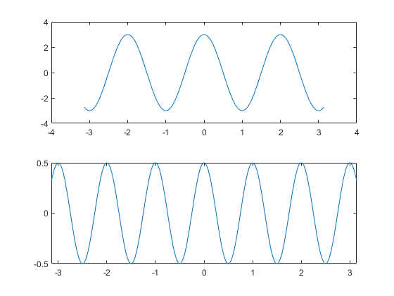

```matlab
syms t a b

f = a*cos(b*t);

%% Method 1: Using subs
f_numeric1 = subs(f, [a, b], [3, pi]); % a=3, b=pi
t_vals = -pi:0.001:pi;
f_val1 = double(subs(f_numeric1, t, t_vals));

subplot(2,1,1)
plot(t_vals, f_val1)


%% Method 2: Using fplot with different parameters
f_numeric2 = subs(f, [a, b], [0.5, 2*pi]); % a=0.5, b=2*pi
subplot(2,1,2)
fplot(f_numeric2, [-pi, pi])
```

## Symbolic Z-Transform Examples

We can compute Z-transforms symbolically using MATLAB's `ztrans` function.

For function documentaion:

- [ztrans](https://www.mathworks.com/help/symbolic/sym.ztrans.html)
- [iztrans](https://www.mathworks.com/help/symbolic/sym.iztrans.html)

```matlab
% 1. Simple Sequence
syms n omega
f1 = sin(n * omega);
fz1 = ztrans(f1);
disp('Z-transform of sin(n):')
disp(fz1)
```

```
Z-transform of sin(n):
(z*sin(omega))/(z^2 - 2*cos(omega)*z + 1)
```

```matlab
% 2. Complex Exponential
syms m n
f2 = exp(m+n);
fz2 = ztrans(f2);
disp('Z-transform of exp(m+n):')
disp(fz2)
```

```
Z-transform of exp(m+n):
(z*exp(m))/(z - exp(1))
```

```matlab
syms y n

f3 = cos(n);
% Transform with respect to y (though f is function of n, this treats n as constant if not specified properly, but here ztrans(f, y) transforms n -> y)
% Actually, standard usage is ztrans(f, n, z) or just ztrans(f)
% If we use ztrans(f, y), the resulting variable is y.
fz3 = ztrans(f3, y);
disp('Z-transform with output variable y:')
disp(fz3)
```

```
Z-transform with output variable y:
(y*(y - cos(1)))/(y^2 - 2*cos(1)*y + 1)
```

Find Inverse Z transfrom of: $$ F = \frac{2z}{(z-2)^2} $$

```matlab
syms z
F = 2*z/(z-2)^2;
f_inv = iztrans(F);
disp('Inverse Z-transform of 2z/(z-2)^2:')
disp(f_inv)
```

```
Inverse Z-transform of 2z/(z-2)^2:
2^n + 2^n*(n - 1)
```

```
Z-transform of u(n-3):
(1/(z - 1) + 1)/z^3

Inverse Z-transform of Z-transform of u(n-3):
1 - kroneckerDelta(n - 2, 0) - kroneckerDelta(n, 0) - kroneckerDelta(n - 1, 0)
```

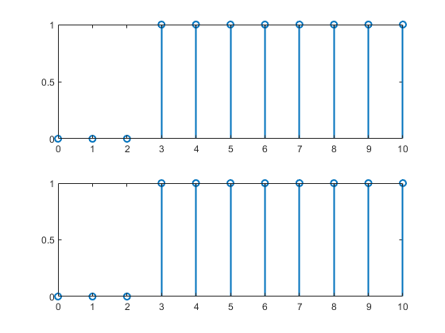

```matlab
syms z n
% Set Heaviside preference for discrete signals
sympref('HeavisideAtOrigin', 1);

fx = heaviside(n-3);
x_axis = 0:10;
fx_y = double(subs(fx, n, x_axis));
subplot(2,1,1)
stem(x_axis, fx_y, 'LineWidth', 1.5)

% Transform fx(n-3)
fz4 = ztrans(fx, n, z);
disp('Z-transform of u(n-3):')
disp(fz4)

% Inverse Z-Transform
ifz = iztrans(fz4, z, n);
disp('Inverse Z-transform of Z-transform of u(n-3):')
disp(ifz)
% 5. Inverse Z-Transform
ifz_y = double(subs(ifz, n, 0:10));
subplot(2,1,2)
stem(x_axis, ifz_y, 'LineWidth', 1.5)
```

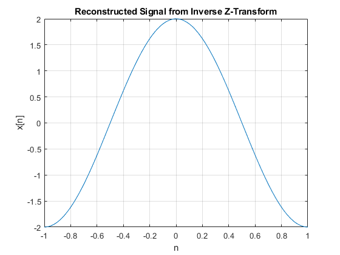

```matlab
clc; clear all;
syms n z a b
fx = a*cos(b*n);
fz = ztrans(fx, n, z);

fx_ = iztrans(fz, z, n);

% Substitute parameters and evaluate
t_vals = -1:0.01:1;

% Note: fx_ is a function of n (discrete), but we are evaluating it over continuous range here for visualization
fx_res = double(subs(fx_, [a b n], {2, pi, t_vals}));

plot(t_vals, fx_res)
title('Reconstructed Signal from Inverse Z-Transform')
xlabel('n')
ylabel('x[n]')
grid on
```

## Lab Task

**Determine the Z-transform and its inverse for**

$$ x(n) = n \cdot \sin(15n) + e^{-3n} $$

- plot the function before and after conversion

[output not shown]

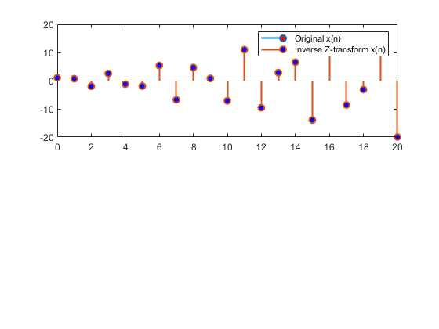

## Assignment

**Using the properties of Z-transform, get $f(n)$, where**

$$ f(n) = x(n) * y(n), \quad * \text{ is the convolution symbol} $$

$$ x(n) = e^{-10n} U(n), \quad y(n) = (1 + n)U(n) $$

**Tasks:**

1. Plot $f(n)$ using Z-transform property ($F(z) = X(z)Y(z)$).
2. Use `conv` function to plot result of `conv(x, y)` and compare.

```
The symbolic expression for f(n) is:
(exp(-10)^n - kroneckerDelta(n, 0))/(exp(20) - 2*exp(10) + 1) + kroneckerDelta(n, 0) + ((kroneckerDelta(n, 0) - 1)*(3*exp(10) - 2*exp(20)))/(exp(20) - 2*exp(10) + 1) - ((exp(10) - exp(20))*(n + kroneckerDelta(n, 0) - 1))/(exp(20) - 2*exp(10) + 1)
```

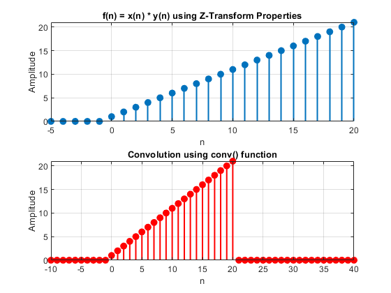